# Correlation between fixed telecommunications infrastructure and basic infrastructure development

Guillermo Fernández Castellanos

20 October 2014

### Introduction:

Broadband adoption is often considered as a driver for development, both economic and otherwise. Different studies tend to confirm this finding, among many others:

- Katz, based on a latinamerican region’s study, showed in 2009 that an increase of ten points in the level of digitalisation results in an increment of 0.59% of GDP
- Czernich proposed in 2009 based on a study of OECD countries that an increase of 10% in broadband penetration results in an increment of GDP between 0.9% and 1.5%
- Koutrompis established in 2009 based on 22 OECD countries that an increase of 1% in broadband penetration resulted in 0.025% growth of the economy

This has resulted in broadband being at the forefront of governments’ priorities. While this applies worldwide, it is specially true for Mexico: the recent telecommunication reform has resulted in an independent regulator, a change of the constitution to include broadband development and initiatives and the development of secondary telecom-related laws. A key factor for broadband adoption is availability: if there is no telecommunication infrastructure, there will be no broadband adoption.

Mexico is a country of inequalities in terms of geography, economy and development, and too often households lack basic infrastructure such as electric light, water through pipes and sewers, let alone telecommunications infrastructure. In this context, we want to understand the correlation between telecommunications infrastructure development (and more specifically fixed infrastructure) and the development of basic infrastructure, and potential sinergies that might exist between the deployment of both.

### Data:

The source for this analysis is the [Mexican 2010 census](http://www.censo2010.org.mx/) made by the National Institute of Statistics and Geography of Mexico, [INEGI](http://www.inegi.org.mx/). The database can be [downloaded from here](http://www3.inegi.org.mx/sistemas/biblioteca/detalle.aspx?c=27623&s=est&upc=702825002065&pf=pob&f=2&cl=0&tg=0).

Despite being called a census, the data has been gathered through quizzes made to 2.9 million households (the case of the database) selected based on probabilistic criterias, avoiding duplications of households. It is an observational study as the data was obtained without directly interfering with households’ activity, and is based on past data.

For localities less than 1100 households all households were censed, while for larger localitices a representative fraction of households only were censed. When only a subset of households are sampled, households are chosen as to be geographically distributed over the given locality (for instance, in terms of blocks for large cities).

The data was then treated and aggregated in localidades (localities), municipios (municipalities composed of several localities) and estados (states) by INEGI. An estado is divided into municipalidades that are composed of one or more localidades.

One significant source of bias comes from non-response, as many smaller localities where not sampled for variables other than population, and with good reason: there are 198500 localities, of which 85000 have 10 or less inhabitants, and 142100 have 100 or less inhabitants. Another source of bias is the fact that non-inhabited households were not accounted within the survey. To minimize the impact of biases it was decided to analize the data at municipio level, as the data will be more aggregated, thus reducing outliers.

The present study will concentrate on potential correlation between two variables:

- Ordered categorical variable: Proportion of particular occupied households with electric light, water through pipes and sewers
- Ordered categorical variable: Proportion of particular occupied households that have fixed telephony line (Viviendas particulares habitadas que disponen de línea telefonica fija)

Both variables can take the values:*0-10%*, *11-20%*, *21-30%*, *31-40%*, *41-50%*, *51-60%*, *61-70%*, *71-80%*, *81-90%* OR *91-100%*.

The proportion of households that have fixed telephony line are used here as a proxy for telecommunication infrastructure deployment. The proxy suffers from known issues:

- television, and not voice, is the preferred service among poor households - which are more likely to lack basic infrastructure
- the variable does not take into account households covered by telecommunication infrastructure but where no service is provided

Nonetheless, fixed line adoption remains the best proxy in view of the reticence of operators to publicly share their coverage information.

Based on those decisions, we prepare the data to respond to our requirements – see Annex 1 for further details.

This study is generalizable to municipios in Mexico - as it is self-contained (we already have present data for all municipios) it should be applied as a forecasting and policy making tool, supporting (or not) the relevance of developping both types of infrastructure. While due to the fact that it is not an experiment with random assignements this data can not be used to establish casual links - and thus causation between both variables - it can show correlation between both variables.

### Exploratory data analysis:

There are 2456 municipios in the database, covering the whole of Mexico. Shown below is the number of municipios per concept and proportion range:

|  | 0-10% | 11-20% | 21-30% | 31-40% | 41-50% | 51-60% | 61-70% | 71-80% | 81-90% | 91-100% |
| --- | --- | --- | --- | --- | --- | --- | --- | --- | --- | --- |
| Basic infrastructure | 110 | 123 | 134 | 166 | 194 | 237 | 282 | 334 | 462 | 414 |
| Fixed line | 500 | 652 | 502 | 393 | 267 | 102 | 23 | 13 | 4 | 0 |

As the figure below left shows, both variables’ probability distribution functions are unimodal and significantly skewed, left skewed for basic infrastructure and right skewed for telecommunications infrastructure. A preliminar analysis indicate a certain relationship between both variables: while there is no apparent linearity it appears clearly in the contingency table (presented graphically below right) that higher proportions of fixed line penetration among households are far more likely in municipios with a high proportion of households with basic infrastructure needs covered. Nonetheless, having a high penetration of basic infrastructure in a municipio does not insure a high adoption of fixed lines among households - fixed infrastructure has been traditionally installed after deployment of basic infrastructures

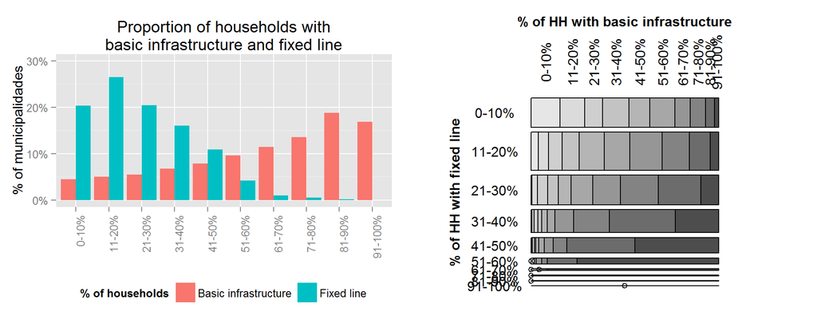

While the concept of mean and median does not make much sense in categorical variables, as in this case they are ordered it is possible to affirm based on their cumulative probability distributions above that the median would be located in the *61-70%* category for basic infrastructure adoption and *21-30%* category for fixed line adoption.

### Inference:

The data is composed of categorical variables of 10 levels each, which will require the chi-square independence test to analyze any relationship between them. This method allows to compare two distributions with categorical variables with more than 2 levels, and evaluate the level of relationship between the two variables, although it does not provide information on causality - only correlation. The test looks at the combination of both variables in a contingency table and quantifies the deviations between the observed variables and the values they would have theoretically had if they were intependent.

This is done by analyzing the distance of the number of observations of each combination of variables against the theoretical values they would have if the null hipotesis was true. The sum of the distances of each combination is used as an input for the chi-square probability distribution, which provides the p-value for the probability that both variables are independent.

In this case, the hypothesis testing is very straightforward:

- *H0 (nothing going on):* Basic infrastructure and telecommunication infrastructure are independent, and telco infrastructure do not vary by the level of development of basic infrastructure.
- *HA (something going on):* Basic infrastructure and telecommunication infrastructure are dependent, and telco infrastructure do vary by the level of development of basic infrastructure.

The table of proportions for the data set is as follows:

```
##                     Fixed line
## Basic infrastructure 0-10% 11-20% 21-30% 31-40% 41-50% 51-60% 61-70%
##              0-10%    0.03   0.01   0.00   0.00   0.00   0.00   0.00
##              11-20%   0.03   0.01   0.01   0.00   0.00   0.00   0.00
##              21-30%   0.02   0.02   0.01   0.00   0.00   0.00   0.00
##              31-40%   0.03   0.02   0.01   0.00   0.00   0.00   0.00
##              41-50%   0.02   0.04   0.01   0.00   0.00   0.00   0.00
##              51-60%   0.03   0.04   0.02   0.01   0.00   0.00   0.00
##              61-70%   0.02   0.05   0.03   0.02   0.01   0.00   0.00
##              71-80%   0.02   0.04   0.04   0.03   0.01   0.00   0.00
##              81-90%   0.01   0.03   0.05   0.06   0.04   0.01   0.00
##              91-100%  0.00   0.01   0.02   0.04   0.05   0.03   0.01
##                     Fixed line
## Basic infrastructure 71-80% 81-90% 91-100%
##              0-10%     0.00   0.00    0.00
##              11-20%    0.00   0.00    0.00
##              21-30%    0.00   0.00    0.00
##              31-40%    0.00   0.00    0.00
##              41-50%    0.00   0.00    0.00
##              51-60%    0.00   0.00    0.00
##              61-70%    0.00   0.00    0.00
##              71-80%    0.00   0.00    0.00
##              81-90%    0.00   0.00    0.00
##              91-100%   0.00   0.00    0.00
```

The first step is to check the conditions for the use of the test are met.

```
##                     Fixed line
## Basic infrastructure 0-10% 11-20% 21-30% 31-40% 41-50% 51-60% 61-70%
##              0-10%      78     26      3      2      1      0      0
##              11-20%     65     35     15      5      1      2      0
##              21-30%     48     48     27      8      3      0      0
##              31-40%     70     58     28      8      2      0      0
##              41-50%     56     88     34     11      4      0      1
##              51-60%     66     88     58     16      8      1      0
##              61-70%     41    112     74     39     13      3      0
##              71-80%     41     95    101     75     19      3      0
##              81-90%     23     72    114    138     97     16      1
##              91-100%    12     30     48     91    119     77     21
##                     Fixed line
## Basic infrastructure 71-80% 81-90% 91-100%
##              0-10%        0      0       0
##              11-20%       0      0       0
##              21-30%       0      0       0
##              31-40%       0      0       0
##              41-50%       0      0       0
##              51-60%       0      0       0
##              61-70%       0      0       0
##              71-80%       0      0       0
##              81-90%       1      0       0
##              91-100%     12      4       0
```

If we had any doubt, the *sample size* condition invalidates the use of the chi-square independence test. The solution is to use simulation methods:

```r
source("http://bit.ly/dasi_inference")
inference(x = droplevels(df$telco), y = droplevels(df$infr),
          est="proportion", type="ht",
          method="simulation", alternative = 'greater',
          sum_stats = FALSE, inf_plot = FALSE, eda_plot = FALSE)
```

```
## Response variable: categorical, Explanatory variable: categorical
## Chi-square test of independence
## H_0: Response and explanatory variable are independent.
## H_A: Response and explanatory variable are dependent.
##
##  Pearson's Chi-squared test with simulated p-value (based on 10000
##  replicates)
##
## data:  y_table
## X-squared = 1432, df = NA, p-value = 9.999e-05
```

We observe a p-value that tends to zero, which provides convincing evidence to reject the H0 hypothesis and conclude that basic infrastructure development and telecommunications infrastructure are associated.

Having used the chi-square independence tests, and unlike other methods that allow for comparisons between hypothesis test and confidence intervals, there ar no other methods applicable that could be used to contrast our results.

### Conclusion:

The analysis shows that it is worth considering basic infrastructure and telecommunications infrastructure development together when developping public policies and infrastructure plans in Mexico, either by leveraging on basic infrastructure to deploy telecommunications infrastructure, or by deploying both simultaneously.

It is nonetheless important to keep in mind the high level of uncertainty associated to our conclusions, due to the lack of precision introduced by the use of fixed line as proxy for the availability for telecommunications infrastructure.

```r
ME <- 0.05
p <- 0.5  # The most conservative ME happens with p = 50%
sample.size <- ceiling(1.96^2 * p*(1 - p)/ME^2)
sample.size
```

```
## [1] 385
```

This amounts to a survey of size of at least 945560 households, which would be impractical and expensive, an alternative being doing it at estado level, with a sample of size 12320, or significantly reducing the level of estados by grouping them based on population.

Another interesing path for future research would be to consider the same relationship at a lower level of detail - localidades. This analysis would have to first tackle the problem of lack of information in localidades with very low population levels, likely by using approximations or considerding very low levels of infrastructure penetration.

### References

[Mexican 2010 census](http://www.censo2010.org.mx/), National Institute of Statistics and Geography of Mexico, [INEGI](http://www.inegi.org.mx/) - [download online](http://www3.inegi.org.mx/sistemas/biblioteca/detalle.aspx?c=27623&s=est&upc=702825002065&pf=pob&f=2&cl=0&tg=0).

Katz, R. L. (2009d). Estimating broadband demand and its economic impact in Latin America. Paper submitted to the ACORN REDECOM Conference 2009, Mexico City, September 5, 2009.

Czernich, N., Falck, O., Kretschmer T., & Woessman, L. (2009, December). Broadband infrastructure and economic growth (CESifo Working Paper No. 2861)

Koutroumpis, P. (2009). The Economic Impact of Broadband on Growth: A Simultaneous Approach. Telecommunications Policy, 33, 471-485.

### Appendix 1: Overview of the database

Find hereafter the commands executed to adapt the database to the study needs:

```r
library(foreign)
df <- read.dbf("ITER_NALDBF10.dbf")

# We are looking only for total Municipio lines
df <- df[df$NOM_LOC == "Total del Municipio", ]

# Change factor types to appropiate types (character or numeric)
as.numeric.factor <- function(x) {as.numeric(levels(x))[x]}
df$NOM_MUN <- as.character.factor(df$NOM_MUN)
df$POBTOT <- as.numeric.factor(df$POBTOT)
df$VIVPAR_HAB <- as.numeric.factor(df$VIVPAR_HAB)
df$VPH_C_SERV <- as.numeric.factor(df$VPH_C_SERV)
df$VPH_TELEF <- as.numeric.factor(df$VPH_TELEF)

# Transform integers to proportions
df$infr <- df$VPH_C_SERV/df$VIVPAR_HAB
df$telco <- df$VPH_TELEF/df$VIVPAR_HAB

# Change numeric variables to categorical variables
percent.limits <- c("0-10%", "11-20%", "21-30%", "31-40%", "41-50%",
                    "51-60%", "61-70%", "71-80%", "81-90%", "91-100%")
df$infr <- cut(df$infr, breaks=seq(0, 1, by = 0.1),
    labels=percent.limits, include.lowest=TRUE)
df$telco <- cut(df$telco, breaks=seq(0, 1, by = 0.1),
    labels=percent.limits, include.lowest=TRUE)

# Add an id to each municipio based on INEGI codes
df$id <-  paste0(df$ENTIDAD, df$MUN)
# Reorder and eliminate undeeded columns
df <- df[, c("id", "infr", "telco")]

# Remove row names
row.names(df)<-NULL
```

This results in the following database (only 40 first rows shown):

```
##       id    infr  telco
## 1  01001 91-100% 51-60%
## 2  01002  81-90% 21-30%
## 3  01003 91-100% 41-50%
## 4  01004 91-100% 21-30%
## 5  01005 91-100% 41-50%
## 6  01006 91-100% 31-40%
## 7  01007 91-100% 21-30%
## 8  01008  81-90% 31-40%
## 9  01009 91-100% 11-20%
## 10 01010  81-90% 11-20%
## 11 01011 91-100% 21-30%
## 12 02001  71-80% 41-50%
## 13 02002 91-100% 51-60%
## 14 02003  81-90% 41-50%
```

[output cut: 26 more lines]